# Risk Factor Analysis

## Outcome Variable

**Outcome Variable:** y_rate_haz

## Predictor Variables

**Intervention Variable:** safeh20

**Adjustment Set:**

- arm
- sex
- W_mage
- meducyrs
- feducyrs
- hhwealth_quart
- hfoodsec
- W_mhtcm
- W_mwtkg
- W_mbmi
- W_nrooms
- W_nchldlt5
- impfloor
- impsan
- delta_W_mage
- delta_meducyrs
- delta_feducyrs
- delta_hhwealth_quart
- delta_hfoodsec
- delta_W_mhtcm
- delta_W_mwtkg
- delta_W_mbmi
- delta_W_nrooms
- delta_W_nchldlt5
- delta_impfloor
- delta_impsan

## Stratifying Variables

The analysis was stratified on these variable(s):

- agecat
- studyid
- country

## Data Summary

| agecat | studyid | country | safeh20 | n_cell | n | outcome_variable |
| --- | --- | --- | --- | --- | --- | --- |
| 0-3 months | ki0047075b-MAL-ED | BANGLADESH | 1 | 0 | 236 | y_rate_haz |
| 0-3 months | ki0047075b-MAL-ED | BANGLADESH | 0 | 236 | 236 | y_rate_haz |
| 0-3 months | ki0047075b-MAL-ED | BRAZIL | 1 | 0 | 116 | y_rate_haz |
| 0-3 months | ki0047075b-MAL-ED | BRAZIL | 0 | 116 | 116 | y_rate_haz |
| 0-3 months | ki0047075b-MAL-ED | INDIA | 1 | 0 | 177 | y_rate_haz |
| 0-3 months | ki0047075b-MAL-ED | INDIA | 0 | 177 | 177 | y_rate_haz |
| 0-3 months | ki0047075b-MAL-ED | NEPAL | 1 | 1 | 153 | y_rate_haz |
| 0-3 months | ki0047075b-MAL-ED | NEPAL | 0 | 152 | 153 | y_rate_haz |
| 0-3 months | ki0047075b-MAL-ED | PERU | 1 | 11 | 243 | y_rate_haz |
| 0-3 months | ki0047075b-MAL-ED | PERU | 0 | 232 | 243 | y_rate_haz |
| 0-3 months | ki0047075b-MAL-ED | SOUTH AFRICA | 1 | 31 | 196 | y_rate_haz |
| 0-3 months | ki0047075b-MAL-ED | SOUTH AFRICA | 0 | 165 | 196 | y_rate_haz |
| 0-3 months | ki0047075b-MAL-ED | TANZANIA, UNITED REPUBLIC OF | 1 | 155 | 224 | y_rate_haz |
| 0-3 months | ki0047075b-MAL-ED | TANZANIA, UNITED REPUBLIC OF | 0 | 69 | 224 | y_rate_haz |
| 0-3 months | ki1017093-NIH-Birth | BANGLADESH | 1 | 564 | 566 | y_rate_haz |
| 0-3 months | ki1017093-NIH-Birth | BANGLADESH | 0 | 2 | 566 | y_rate_haz |
| 0-3 months | ki1017093b-PROVIDE | BANGLADESH | 1 | 13 | 13 | y_rate_haz |
| 0-3 months | ki1017093b-PROVIDE | BANGLADESH | 0 | 0 | 13 | y_rate_haz |
| 0-3 months | ki1017093c-NIH-Crypto | BANGLADESH | 1 | 721 | 721 | y_rate_haz |
| 0-3 months | ki1017093c-NIH-Crypto | BANGLADESH | 0 | 0 | 721 | y_rate_haz |
| 0-3 months | ki1114097-CONTENT | PERU | 1 | 5 | 6 | y_rate_haz |
| 0-3 months | ki1114097-CONTENT | PERU | 0 | 1 | 6 | y_rate_haz |
| 0-3 months | kiGH5241-JiVitA-3 | BANGLADESH | 1 | 19829 | 19863 | y_rate_haz |
| 0-3 months | kiGH5241-JiVitA-3 | BANGLADESH | 0 | 34 | 19863 | y_rate_haz |
| 0-3 months | kiGH5241-JiVitA-4 | BANGLADESH | 1 | 2513 | 2513 | y_rate_haz |
| 0-3 months | kiGH5241-JiVitA-4 | BANGLADESH | 0 | 0 | 2513 | y_rate_haz |
| 3-6 months | ki0047075b-MAL-ED | BANGLADESH | 1 | 0 | 231 | y_rate_haz |
| 3-6 months | ki0047075b-MAL-ED | BANGLADESH | 0 | 231 | 231 | y_rate_haz |
| 3-6 months | ki0047075b-MAL-ED | BRAZIL | 1 | 0 | 141 | y_rate_haz |
| 3-6 months | ki0047075b-MAL-ED | BRAZIL | 0 | 141 | 141 | y_rate_haz |

[output cut: 182 more lines]

The following strata were considered:

- agecat: 0-3 months, studyid: ki0047075b-MAL-ED, country: BANGLADESH
- agecat: 0-3 months, studyid: ki0047075b-MAL-ED, country: BRAZIL
- agecat: 0-3 months, studyid: ki0047075b-MAL-ED, country: INDIA
- agecat: 0-3 months, studyid: ki0047075b-MAL-ED, country: NEPAL
- agecat: 0-3 months, studyid: ki0047075b-MAL-ED, country: PERU
- agecat: 0-3 months, studyid: ki0047075b-MAL-ED, country: SOUTH AFRICA
- agecat: 0-3 months, studyid: ki0047075b-MAL-ED, country: TANZANIA, UNITED REPUBLIC OF
- agecat: 0-3 months, studyid: ki1017093-NIH-Birth, country: BANGLADESH
- agecat: 0-3 months, studyid: ki1017093b-PROVIDE, country: BANGLADESH
- agecat: 0-3 months, studyid: ki1017093c-NIH-Crypto, country: BANGLADESH
- agecat: 0-3 months, studyid: ki1114097-CONTENT, country: PERU
- agecat: 0-3 months, studyid: kiGH5241-JiVitA-3, country: BANGLADESH
- agecat: 0-3 months, studyid: kiGH5241-JiVitA-4, country: BANGLADESH
- agecat: 12-15 months, studyid: ki0047075b-MAL-ED, country: BANGLADESH
- agecat: 12-15 months, studyid: ki0047075b-MAL-ED, country: BRAZIL
- agecat: 12-15 months, studyid: ki0047075b-MAL-ED, country: INDIA
- agecat: 12-15 months, studyid: ki0047075b-MAL-ED, country: NEPAL
- agecat: 12-15 months, studyid: ki0047075b-MAL-ED, country: PERU
- agecat: 12-15 months, studyid: ki0047075b-MAL-ED, country: SOUTH AFRICA
- agecat: 12-15 months, studyid: ki0047075b-MAL-ED, country: TANZANIA, UNITED REPUBLIC OF
- agecat: 12-15 months, studyid: ki1000304b-SAS-FoodSuppl, country: INDIA
- agecat: 12-15 months, studyid: ki1017093-NIH-Birth, country: BANGLADESH
- agecat: 12-15 months, studyid: ki1017093b-PROVIDE, country: BANGLADESH
- agecat: 12-15 months, studyid: ki1017093c-NIH-Crypto, country: BANGLADESH
- agecat: 12-15 months, studyid: ki1114097-CONTENT, country: PERU
- agecat: 12-15 months, studyid: ki1148112-LCNI-5, country: MALAWI
- agecat: 12-15 months, studyid: kiGH5241-JiVitA-4, country: BANGLADESH
- agecat: 15-18 months, studyid: ki0047075b-MAL-ED, country: BANGLADESH
- agecat: 15-18 months, studyid: ki0047075b-MAL-ED, country: BRAZIL
- agecat: 15-18 months, studyid: ki0047075b-MAL-ED, country: INDIA
- agecat: 15-18 months, studyid: ki0047075b-MAL-ED, country: NEPAL
- agecat: 15-18 months, studyid: ki0047075b-MAL-ED, country: PERU
- agecat: 15-18 months, studyid: ki0047075b-MAL-ED, country: SOUTH AFRICA
- agecat: 15-18 months, studyid: ki0047075b-MAL-ED, country: TANZANIA, UNITED REPUBLIC OF
- agecat: 15-18 months, studyid: ki1000304b-SAS-FoodSuppl, country: INDIA
- agecat: 15-18 months, studyid: ki1017093-NIH-Birth, country: BANGLADESH
- agecat: 15-18 months, studyid: ki1017093b-PROVIDE, country: BANGLADESH
- agecat: 15-18 months, studyid: ki1017093c-NIH-Crypto, country: BANGLADESH
- agecat: 15-18 months, studyid: ki1114097-CONTENT, country: PERU
- agecat: 15-18 months, studyid: ki1148112-LCNI-5, country: MALAWI
- agecat: 15-18 months, studyid: kiGH5241-JiVitA-4, country: BANGLADESH
- agecat: 18-21 months, studyid: ki0047075b-MAL-ED, country: BANGLADESH
- agecat: 18-21 months, studyid: ki0047075b-MAL-ED, country: BRAZIL
- agecat: 18-21 months, studyid: ki0047075b-MAL-ED, country: INDIA
- agecat: 18-21 months, studyid: ki0047075b-MAL-ED, country: NEPAL
- agecat: 18-21 months, studyid: ki0047075b-MAL-ED, country: PERU
- agecat: 18-21 months, studyid: ki0047075b-MAL-ED, country: SOUTH AFRICA
- agecat: 18-21 months, studyid: ki0047075b-MAL-ED, country: TANZANIA, UNITED REPUBLIC OF
- agecat: 18-21 months, studyid: ki1017093-NIH-Birth, country: BANGLADESH
- agecat: 18-21 months, studyid: ki1017093b-PROVIDE, country: BANGLADESH
- agecat: 18-21 months, studyid: ki1017093c-NIH-Crypto, country: BANGLADESH
- agecat: 18-21 months, studyid: ki1114097-CONTENT, country: PERU
- agecat: 18-21 months, studyid: ki1148112-LCNI-5, country: MALAWI
- agecat: 21-24 months, studyid: ki0047075b-MAL-ED, country: BANGLADESH
- agecat: 21-24 months, studyid: ki0047075b-MAL-ED, country: BRAZIL
- agecat: 21-24 months, studyid: ki0047075b-MAL-ED, country: INDIA
- agecat: 21-24 months, studyid: ki0047075b-MAL-ED, country: NEPAL
- agecat: 21-24 months, studyid: ki0047075b-MAL-ED, country: PERU
- agecat: 21-24 months, studyid: ki0047075b-MAL-ED, country: SOUTH AFRICA
- agecat: 21-24 months, studyid: ki0047075b-MAL-ED, country: TANZANIA, UNITED REPUBLIC OF
- agecat: 21-24 months, studyid: ki1017093-NIH-Birth, country: BANGLADESH
- agecat: 21-24 months, studyid: ki1017093b-PROVIDE, country: BANGLADESH
- agecat: 21-24 months, studyid: ki1017093c-NIH-Crypto, country: BANGLADESH
- agecat: 21-24 months, studyid: ki1114097-CONTENT, country: PERU
- agecat: 21-24 months, studyid: ki1148112-LCNI-5, country: MALAWI
- agecat: 3-6 months, studyid: ki0047075b-MAL-ED, country: BANGLADESH
- agecat: 3-6 months, studyid: ki0047075b-MAL-ED, country: BRAZIL
- agecat: 3-6 months, studyid: ki0047075b-MAL-ED, country: INDIA
- agecat: 3-6 months, studyid: ki0047075b-MAL-ED, country: NEPAL
- agecat: 3-6 months, studyid: ki0047075b-MAL-ED, country: PERU
- agecat: 3-6 months, studyid: ki0047075b-MAL-ED, country: SOUTH AFRICA
- agecat: 3-6 months, studyid: ki0047075b-MAL-ED, country: TANZANIA, UNITED REPUBLIC OF
- agecat: 3-6 months, studyid: ki1017093-NIH-Birth, country: BANGLADESH
- agecat: 3-6 months, studyid: ki1017093b-PROVIDE, country: BANGLADESH
- agecat: 3-6 months, studyid: ki1017093c-NIH-Crypto, country: BANGLADESH
- agecat: 3-6 months, studyid: ki1114097-CONTENT, country: PERU
- agecat: 3-6 months, studyid: kiGH5241-JiVitA-3, country: BANGLADESH
- agecat: 3-6 months, studyid: kiGH5241-JiVitA-4, country: BANGLADESH
- agecat: 6-9 months, studyid: ki0047075b-MAL-ED, country: BANGLADESH
- agecat: 6-9 months, studyid: ki0047075b-MAL-ED, country: BRAZIL
- agecat: 6-9 months, studyid: ki0047075b-MAL-ED, country: INDIA
- agecat: 6-9 months, studyid: ki0047075b-MAL-ED, country: NEPAL
- agecat: 6-9 months, studyid: ki0047075b-MAL-ED, country: PERU
- agecat: 6-9 months, studyid: ki0047075b-MAL-ED, country: SOUTH AFRICA
- agecat: 6-9 months, studyid: ki0047075b-MAL-ED, country: TANZANIA, UNITED REPUBLIC OF
- agecat: 6-9 months, studyid: ki1000304b-SAS-FoodSuppl, country: INDIA
- agecat: 6-9 months, studyid: ki1017093-NIH-Birth, country: BANGLADESH
- agecat: 6-9 months, studyid: ki1017093b-PROVIDE, country: BANGLADESH
- agecat: 6-9 months, studyid: ki1017093c-NIH-Crypto, country: BANGLADESH
- agecat: 6-9 months, studyid: ki1114097-CONTENT, country: PERU
- agecat: 6-9 months, studyid: ki1148112-LCNI-5, country: MALAWI
- agecat: 6-9 months, studyid: kiGH5241-JiVitA-4, country: BANGLADESH
- agecat: 9-12 months, studyid: ki0047075b-MAL-ED, country: BANGLADESH
- agecat: 9-12 months, studyid: ki0047075b-MAL-ED, country: BRAZIL
- agecat: 9-12 months, studyid: ki0047075b-MAL-ED, country: INDIA
- agecat: 9-12 months, studyid: ki0047075b-MAL-ED, country: NEPAL
- agecat: 9-12 months, studyid: ki0047075b-MAL-ED, country: PERU
- agecat: 9-12 months, studyid: ki0047075b-MAL-ED, country: SOUTH AFRICA
- agecat: 9-12 months, studyid: ki0047075b-MAL-ED, country: TANZANIA, UNITED REPUBLIC OF
- agecat: 9-12 months, studyid: ki1000304b-SAS-FoodSuppl, country: INDIA
- agecat: 9-12 months, studyid: ki1017093-NIH-Birth, country: BANGLADESH
- agecat: 9-12 months, studyid: ki1017093b-PROVIDE, country: BANGLADESH
- agecat: 9-12 months, studyid: ki1017093c-NIH-Crypto, country: BANGLADESH
- agecat: 9-12 months, studyid: ki1114097-CONTENT, country: PERU
- agecat: 9-12 months, studyid: ki1148112-LCNI-5, country: MALAWI
- agecat: 9-12 months, studyid: kiGH5241-JiVitA-4, country: BANGLADESH

### Dropped Strata

Some strata were dropped due to rare outcomes:

- agecat: 0-3 months, studyid: ki0047075b-MAL-ED, country: BANGLADESH
- agecat: 0-3 months, studyid: ki0047075b-MAL-ED, country: BRAZIL
- agecat: 0-3 months, studyid: ki0047075b-MAL-ED, country: INDIA
- agecat: 0-3 months, studyid: ki0047075b-MAL-ED, country: NEPAL
- agecat: 0-3 months, studyid: ki1017093-NIH-Birth, country: BANGLADESH
- agecat: 0-3 months, studyid: ki1017093b-PROVIDE, country: BANGLADESH
- agecat: 0-3 months, studyid: ki1017093c-NIH-Crypto, country: BANGLADESH
- agecat: 0-3 months, studyid: ki1114097-CONTENT, country: PERU
- agecat: 0-3 months, studyid: kiGH5241-JiVitA-4, country: BANGLADESH
- agecat: 3-6 months, studyid: ki0047075b-MAL-ED, country: BANGLADESH
- agecat: 3-6 months, studyid: ki0047075b-MAL-ED, country: BRAZIL
- agecat: 3-6 months, studyid: ki0047075b-MAL-ED, country: INDIA
- agecat: 3-6 months, studyid: ki0047075b-MAL-ED, country: NEPAL
- agecat: 3-6 months, studyid: ki1017093-NIH-Birth, country: BANGLADESH
- agecat: 3-6 months, studyid: ki1017093b-PROVIDE, country: BANGLADESH
- agecat: 3-6 months, studyid: ki1017093c-NIH-Crypto, country: BANGLADESH
- agecat: 3-6 months, studyid: ki1114097-CONTENT, country: PERU
- agecat: 3-6 months, studyid: kiGH5241-JiVitA-4, country: BANGLADESH
- agecat: 6-9 months, studyid: ki0047075b-MAL-ED, country: BANGLADESH
- agecat: 6-9 months, studyid: ki0047075b-MAL-ED, country: BRAZIL
- agecat: 6-9 months, studyid: ki0047075b-MAL-ED, country: INDIA
- agecat: 6-9 months, studyid: ki0047075b-MAL-ED, country: NEPAL
- agecat: 6-9 months, studyid: ki1000304b-SAS-FoodSuppl, country: INDIA
- agecat: 6-9 months, studyid: ki1017093-NIH-Birth, country: BANGLADESH
- agecat: 6-9 months, studyid: ki1017093b-PROVIDE, country: BANGLADESH
- agecat: 6-9 months, studyid: ki1017093c-NIH-Crypto, country: BANGLADESH
- agecat: 6-9 months, studyid: ki1114097-CONTENT, country: PERU
- agecat: 6-9 months, studyid: kiGH5241-JiVitA-4, country: BANGLADESH
- agecat: 9-12 months, studyid: ki0047075b-MAL-ED, country: BANGLADESH
- agecat: 9-12 months, studyid: ki0047075b-MAL-ED, country: BRAZIL
- agecat: 9-12 months, studyid: ki0047075b-MAL-ED, country: INDIA
- agecat: 9-12 months, studyid: ki0047075b-MAL-ED, country: NEPAL
- agecat: 9-12 months, studyid: ki1000304b-SAS-FoodSuppl, country: INDIA
- agecat: 9-12 months, studyid: ki1017093-NIH-Birth, country: BANGLADESH
- agecat: 9-12 months, studyid: ki1017093b-PROVIDE, country: BANGLADESH
- agecat: 9-12 months, studyid: ki1017093c-NIH-Crypto, country: BANGLADESH
- agecat: 9-12 months, studyid: ki1114097-CONTENT, country: PERU
- agecat: 9-12 months, studyid: kiGH5241-JiVitA-4, country: BANGLADESH
- agecat: 12-15 months, studyid: ki0047075b-MAL-ED, country: BANGLADESH
- agecat: 12-15 months, studyid: ki0047075b-MAL-ED, country: BRAZIL
- agecat: 12-15 months, studyid: ki0047075b-MAL-ED, country: INDIA
- agecat: 12-15 months, studyid: ki0047075b-MAL-ED, country: NEPAL
- agecat: 12-15 months, studyid: ki1000304b-SAS-FoodSuppl, country: INDIA
- agecat: 12-15 months, studyid: ki1017093-NIH-Birth, country: BANGLADESH
- agecat: 12-15 months, studyid: ki1017093b-PROVIDE, country: BANGLADESH
- agecat: 12-15 months, studyid: ki1017093c-NIH-Crypto, country: BANGLADESH
- agecat: 12-15 months, studyid: ki1114097-CONTENT, country: PERU
- agecat: 12-15 months, studyid: kiGH5241-JiVitA-4, country: BANGLADESH
- agecat: 15-18 months, studyid: ki0047075b-MAL-ED, country: BANGLADESH
- agecat: 15-18 months, studyid: ki0047075b-MAL-ED, country: BRAZIL
- agecat: 15-18 months, studyid: ki0047075b-MAL-ED, country: INDIA
- agecat: 15-18 months, studyid: ki0047075b-MAL-ED, country: NEPAL
- agecat: 15-18 months, studyid: ki1000304b-SAS-FoodSuppl, country: INDIA
- agecat: 15-18 months, studyid: ki1017093-NIH-Birth, country: BANGLADESH
- agecat: 15-18 months, studyid: ki1017093b-PROVIDE, country: BANGLADESH
- agecat: 15-18 months, studyid: ki1017093c-NIH-Crypto, country: BANGLADESH
- agecat: 15-18 months, studyid: ki1114097-CONTENT, country: PERU
- agecat: 15-18 months, studyid: kiGH5241-JiVitA-4, country: BANGLADESH
- agecat: 18-21 months, studyid: ki0047075b-MAL-ED, country: BANGLADESH
- agecat: 18-21 months, studyid: ki0047075b-MAL-ED, country: BRAZIL
- agecat: 18-21 months, studyid: ki0047075b-MAL-ED, country: INDIA
- agecat: 18-21 months, studyid: ki0047075b-MAL-ED, country: NEPAL
- agecat: 18-21 months, studyid: ki1017093-NIH-Birth, country: BANGLADESH
- agecat: 18-21 months, studyid: ki1017093b-PROVIDE, country: BANGLADESH
- agecat: 18-21 months, studyid: ki1017093c-NIH-Crypto, country: BANGLADESH
- agecat: 18-21 months, studyid: ki1114097-CONTENT, country: PERU
- agecat: 21-24 months, studyid: ki0047075b-MAL-ED, country: BANGLADESH
- agecat: 21-24 months, studyid: ki0047075b-MAL-ED, country: BRAZIL
- agecat: 21-24 months, studyid: ki0047075b-MAL-ED, country: INDIA
- agecat: 21-24 months, studyid: ki0047075b-MAL-ED, country: NEPAL
- agecat: 21-24 months, studyid: ki1017093-NIH-Birth, country: BANGLADESH
- agecat: 21-24 months, studyid: ki1017093b-PROVIDE, country: BANGLADESH
- agecat: 21-24 months, studyid: ki1017093c-NIH-Crypto, country: BANGLADESH
- agecat: 21-24 months, studyid: ki1114097-CONTENT, country: PERU

## Methods Detail

We’re interested in the causal parameters $E[Y_a]$ for all values of $a \in \mathcal{A}$. These parameters represent the mean outcome if, possibly contrary to fact, we intervened to set all units to have $A=a$. Under the randomization and positivity assumptions, these are identified by the statistical parameters $\psi_a=E_W[E_{Y|A,W}(Y|A=a,W)]$. In addition, we’re interested in the mean of $Y$, $E[Y]$ under no intervention (the observed mean). We will estimate these parameters by using SuperLearner to fit the relevant likelihood factors – $E_{Y|A,W}(Y|A=a,W)$ and $p(A=a|W)$, and then updating our likelihood fit using a joint TMLE.

For unadjusted analyses ($W=\{\}$), initial likelihoods were estimated using Lrnr_glm to estimate the simple $E(Y|A)$ and Lrnr_mean to estimate $p(A)$. For adjusted analyses, a small library containing Lrnr_glmnet, Lrnr_xgboost, and Lrnr_mean was used.

Having estimated these parameters, we will then use the delta method to estimate relative risks and attributable risks relative to a prespecified baseline level of $A$.

# Results Detail

## Results Plots

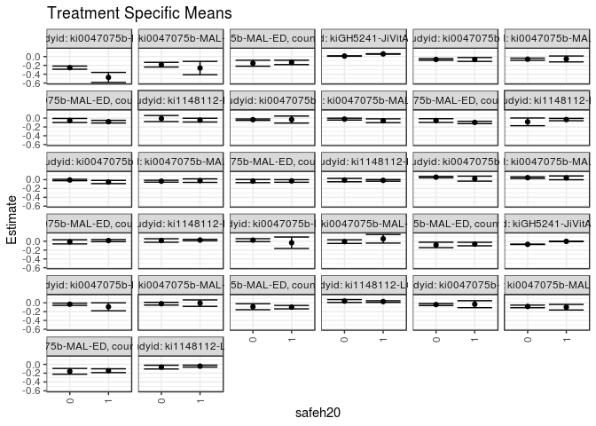

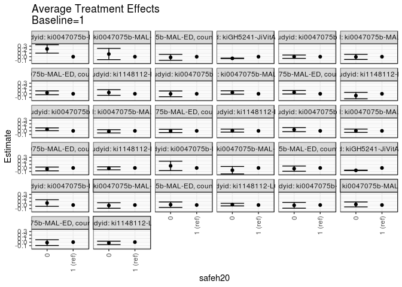

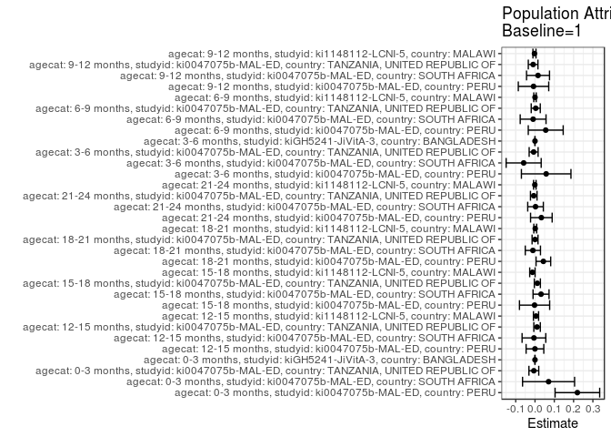

## Results Table

### Parameter: TSM

| agecat | studyid | country | intervention_level | baseline_level | estimate | ci_lower | ci_upper |
| --- | --- | --- | --- | --- | --- | --- | --- |
| 0-3 months | ki0047075b-MAL-ED | PERU | 1 | NA | -0.4722970 | -0.5856010 | -0.3589930 |
| 0-3 months | ki0047075b-MAL-ED | PERU | 0 | NA | -0.2515576 | -0.2871787 | -0.2159365 |
| 0-3 months | ki0047075b-MAL-ED | SOUTH AFRICA | 1 | NA | -0.2603384 | -0.4111373 | -0.1095395 |
| 0-3 months | ki0047075b-MAL-ED | SOUTH AFRICA | 0 | NA | -0.1843162 | -0.2377425 | -0.1308899 |
| 0-3 months | ki0047075b-MAL-ED | TANZANIA, UNITED REPUBLIC OF | 1 | NA | -0.1329742 | -0.1826669 | -0.0832814 |
| 0-3 months | ki0047075b-MAL-ED | TANZANIA, UNITED REPUBLIC OF | 0 | NA | -0.1514944 | -0.2187266 | -0.0842622 |
| 0-3 months | kiGH5241-JiVitA-3 | BANGLADESH | 1 | NA | 0.0589638 | 0.0539209 | 0.0640066 |
| 0-3 months | kiGH5241-JiVitA-3 | BANGLADESH | 0 | NA | 0.0113917 | 0.0069105 | 0.0158729 |
| 3-6 months | ki0047075b-MAL-ED | PERU | 1 | NA | -0.0342899 | -0.1640780 | 0.0954981 |
| 3-6 months | ki0047075b-MAL-ED | PERU | 0 | NA | 0.0244926 | -0.0086001 | 0.0575852 |
| 3-6 months | ki0047075b-MAL-ED | SOUTH AFRICA | 1 | NA | 0.0554530 | -0.0418830 | 0.1527889 |
| 3-6 months | ki0047075b-MAL-ED | SOUTH AFRICA | 0 | NA | -0.0086275 | -0.0500445 | 0.0327895 |
| 3-6 months | ki0047075b-MAL-ED | TANZANIA, UNITED REPUBLIC OF | 1 | NA | -0.0643374 | -0.1041664 | -0.0245084 |
| 3-6 months | ki0047075b-MAL-ED | TANZANIA, UNITED REPUBLIC OF | 0 | NA | -0.0841364 | -0.1458375 | -0.0224353 |
| 3-6 months | kiGH5241-JiVitA-3 | BANGLADESH | 1 | NA | -0.0033702 | -0.0083532 | 0.0016127 |
| 3-6 months | kiGH5241-JiVitA-3 | BANGLADESH | 0 | NA | -0.0708620 | -0.0747028 | -0.0670212 |
| 6-9 months | ki0047075b-MAL-ED | PERU | 1 | NA | -0.0905021 | -0.1807506 | -0.0002535 |
| 6-9 months | ki0047075b-MAL-ED | PERU | 0 | NA | -0.0331023 | -0.0583749 | -0.0078297 |
| 6-9 months | ki0047075b-MAL-ED | SOUTH AFRICA | 1 | NA | -0.0080146 | -0.0809169 | 0.0648877 |
| 6-9 months | ki0047075b-MAL-ED | SOUTH AFRICA | 0 | NA | -0.0208916 | -0.0517800 | 0.0099967 |
| 6-9 months | ki0047075b-MAL-ED | TANZANIA, UNITED REPUBLIC OF | 1 | NA | -0.0989210 | -0.1379574 | -0.0598846 |
| 6-9 months | ki0047075b-MAL-ED | TANZANIA, UNITED REPUBLIC OF | 0 | NA | -0.0888401 | -0.1565087 | -0.0211714 |
| 6-9 months | ki1148112-LCNI-5 | MALAWI | 1 | NA | 0.0279109 | 0.0098190 | 0.0460027 |
| 6-9 months | ki1148112-LCNI-5 | MALAWI | 0 | NA | 0.0399427 | 0.0077603 | 0.0721251 |
| 9-12 months | ki0047075b-MAL-ED | PERU | 1 | NA | -0.0326081 | -0.1116005 | 0.0463844 |
| 9-12 months | ki0047075b-MAL-ED | PERU | 0 | NA | -0.0406500 | -0.0632066 | -0.0180933 |
| 9-12 months | ki0047075b-MAL-ED | SOUTH AFRICA | 1 | NA | -0.1004670 | -0.1640357 | -0.0368982 |
| 9-12 months | ki0047075b-MAL-ED | SOUTH AFRICA | 0 | NA | -0.0827418 | -0.1128190 | -0.0526646 |
| 9-12 months | ki0047075b-MAL-ED | TANZANIA, UNITED REPUBLIC OF | 1 | NA | -0.1441739 | -0.1874811 | -0.1008668 |
| 9-12 months | ki0047075b-MAL-ED | TANZANIA, UNITED REPUBLIC OF | 0 | NA | -0.1583777 | -0.2237545 | -0.0930009 |
| 9-12 months | ki1148112-LCNI-5 | MALAWI | 1 | NA | -0.0405630 | -0.0628504 | -0.0182756 |
| 9-12 months | ki1148112-LCNI-5 | MALAWI | 0 | NA | -0.0629054 | -0.1056533 | -0.0201574 |
| 12-15 months | ki0047075b-MAL-ED | PERU | 1 | NA | -0.0657169 | -0.1092700 | -0.0221637 |
| 12-15 months | ki0047075b-MAL-ED | PERU | 0 | NA | -0.0660215 | -0.0851882 | -0.0468548 |
| 12-15 months | ki0047075b-MAL-ED | SOUTH AFRICA | 1 | NA | -0.0545207 | -0.1218318 | 0.0127904 |
| 12-15 months | ki0047075b-MAL-ED | SOUTH AFRICA | 0 | NA | -0.0601164 | -0.0848791 | -0.0353537 |
| 12-15 months | ki0047075b-MAL-ED | TANZANIA, UNITED REPUBLIC OF | 1 | NA | -0.0807773 | -0.1109974 | -0.0505572 |
| 12-15 months | ki0047075b-MAL-ED | TANZANIA, UNITED REPUBLIC OF | 0 | NA | -0.0533153 | -0.0988130 | -0.0078176 |
| 12-15 months | ki1148112-LCNI-5 | MALAWI | 1 | NA | -0.0455351 | -0.0880994 | -0.0029709 |
| 12-15 months | ki1148112-LCNI-5 | MALAWI | 0 | NA | -0.0097388 | -0.0784429 | 0.0589653 |
| 15-18 months | ki0047075b-MAL-ED | PERU | 1 | NA | -0.0323292 | -0.1121274 | 0.0474690 |
| 15-18 months | ki0047075b-MAL-ED | PERU | 0 | NA | -0.0347368 | -0.0509458 | -0.0185277 |
| 15-18 months | ki0047075b-MAL-ED | SOUTH AFRICA | 1 | NA | -0.0597273 | -0.1032249 | -0.0162298 |
| 15-18 months | ki0047075b-MAL-ED | SOUTH AFRICA | 0 | NA | -0.0226958 | -0.0438968 | -0.0014948 |
| 15-18 months | ki0047075b-MAL-ED | TANZANIA, UNITED REPUBLIC OF | 1 | NA | -0.0978789 | -0.1246858 | -0.0710720 |
| 15-18 months | ki0047075b-MAL-ED | TANZANIA, UNITED REPUBLIC OF | 0 | NA | -0.0550271 | -0.0965833 | -0.0134710 |
| 15-18 months | ki1148112-LCNI-5 | MALAWI | 1 | NA | -0.0329026 | -0.0593716 | -0.0064335 |
| 15-18 months | ki1148112-LCNI-5 | MALAWI | 0 | NA | -0.0848121 | -0.1716592 | 0.0020349 |
| 18-21 months | ki0047075b-MAL-ED | PERU | 1 | NA | -0.0527482 | -0.0889320 | -0.0165645 |
| 18-21 months | ki0047075b-MAL-ED | PERU | 0 | NA | -0.0074914 | -0.0233551 | 0.0083722 |
| 18-21 months | ki0047075b-MAL-ED | SOUTH AFRICA | 1 | NA | -0.0213956 | -0.0612623 | 0.0184711 |
| 18-21 months | ki0047075b-MAL-ED | SOUTH AFRICA | 0 | NA | -0.0344711 | -0.0563219 | -0.0126203 |
| 18-21 months | ki0047075b-MAL-ED | TANZANIA, UNITED REPUBLIC OF | 1 | NA | -0.0290559 | -0.0588319 | 0.0007201 |
| 18-21 months | ki0047075b-MAL-ED | TANZANIA, UNITED REPUBLIC OF | 0 | NA | -0.0312627 | -0.0667073 | 0.0041819 |
| 18-21 months | ki1148112-LCNI-5 | MALAWI | 1 | NA | -0.0158882 | -0.0339845 | 0.0022081 |
| 18-21 months | ki1148112-LCNI-5 | MALAWI | 0 | NA | -0.0090934 | -0.0473890 | 0.0292022 |
| 21-24 months | ki0047075b-MAL-ED | PERU | 1 | NA | 0.0232134 | -0.0327597 | 0.0791864 |
| 21-24 months | ki0047075b-MAL-ED | PERU | 0 | NA | 0.0574631 | 0.0416924 | 0.0732338 |
| 21-24 months | ki0047075b-MAL-ED | SOUTH AFRICA | 1 | NA | 0.0413722 | -0.0015812 | 0.0843255 |
| 21-24 months | ki0047075b-MAL-ED | SOUTH AFRICA | 0 | NA | 0.0449502 | 0.0265757 | 0.0633248 |
| 21-24 months | ki0047075b-MAL-ED | TANZANIA, UNITED REPUBLIC OF | 1 | NA | 0.0147476 | -0.0090291 | 0.0385244 |
| 21-24 months | ki0047075b-MAL-ED | TANZANIA, UNITED REPUBLIC OF | 0 | NA | -0.0137175 | -0.0609986 | 0.0335636 |
| 21-24 months | ki1148112-LCNI-5 | MALAWI | 1 | NA | 0.0268315 | 0.0101805 | 0.0434825 |
| 21-24 months | ki1148112-LCNI-5 | MALAWI | 0 | NA | 0.0163638 | -0.0232459 | 0.0559735 |

### Parameter: E(Y)

| agecat | studyid | country | intervention_level | baseline_level | estimate | ci_lower | ci_upper |
| --- | --- | --- | --- | --- | --- | --- | --- |
| 0-3 months | ki0047075b-MAL-ED | PERU | NA | NA | -0.2525945 | -0.2869213 | -0.2182678 |
| 0-3 months | ki0047075b-MAL-ED | SOUTH AFRICA | NA | NA | -0.1900029 | -0.2411148 | -0.1388910 |
| 0-3 months | ki0047075b-MAL-ED | TANZANIA, UNITED REPUBLIC OF | NA | NA | -0.1389943 | -0.1784707 | -0.0995180 |
| 0-3 months | kiGH5241-JiVitA-3 | BANGLADESH | NA | NA | 0.0588770 | 0.0539560 | 0.0637979 |
| 3-6 months | ki0047075b-MAL-ED | PERU | NA | NA | 0.0236350 | -0.0084722 | 0.0557423 |
| 3-6 months | ki0047075b-MAL-ED | SOUTH AFRICA | NA | NA | -0.0033394 | -0.0413034 | 0.0346246 |
| 3-6 months | ki0047075b-MAL-ED | TANZANIA, UNITED REPUBLIC OF | NA | NA | -0.0714664 | -0.1037306 | -0.0392021 |
| 3-6 months | kiGH5241-JiVitA-3 | BANGLADESH | NA | NA | -0.0034346 | -0.0083001 | 0.0014310 |
| 6-9 months | ki0047075b-MAL-ED | PERU | NA | NA | -0.0349381 | -0.0594933 | -0.0103830 |
| 6-9 months | ki0047075b-MAL-ED | SOUTH AFRICA | NA | NA | -0.0177890 | -0.0460334 | 0.0104554 |
| 6-9 months | ki0047075b-MAL-ED | TANZANIA, UNITED REPUBLIC OF | NA | NA | -0.0951251 | -0.1285712 | -0.0616789 |
| 6-9 months | ki1148112-LCNI-5 | MALAWI | NA | NA | 0.0279334 | 0.0120046 | 0.0438622 |
| 9-12 months | ki0047075b-MAL-ED | PERU | NA | NA | -0.0403297 | -0.0622163 | -0.0184431 |
| 9-12 months | ki0047075b-MAL-ED | SOUTH AFRICA | NA | NA | -0.0847380 | -0.1117373 | -0.0577388 |
| 9-12 months | ki0047075b-MAL-ED | TANZANIA, UNITED REPUBLIC OF | NA | NA | -0.1539778 | -0.1878402 | -0.1201153 |
| 9-12 months | ki1148112-LCNI-5 | MALAWI | NA | NA | -0.0433141 | -0.0626948 | -0.0239333 |
| 12-15 months | ki0047075b-MAL-ED | PERU | NA | NA | -0.0660102 | -0.0845347 | -0.0474856 |
| 12-15 months | ki0047075b-MAL-ED | SOUTH AFRICA | NA | NA | -0.0600337 | -0.0829414 | -0.0371260 |
| 12-15 months | ki0047075b-MAL-ED | TANZANIA, UNITED REPUBLIC OF | NA | NA | -0.0701548 | -0.0952743 | -0.0450353 |
| 12-15 months | ki1148112-LCNI-5 | MALAWI | NA | NA | -0.0403575 | -0.0774359 | -0.0032790 |
| 15-18 months | ki0047075b-MAL-ED | PERU | NA | NA | -0.0346428 | -0.0505277 | -0.0187579 |
| 15-18 months | ki0047075b-MAL-ED | SOUTH AFRICA | NA | NA | -0.0284295 | -0.0474993 | -0.0093597 |
| 15-18 months | ki0047075b-MAL-ED | TANZANIA, UNITED REPUBLIC OF | NA | NA | -0.0857732 | -0.1082180 | -0.0633284 |
| 15-18 months | ki1148112-LCNI-5 | MALAWI | NA | NA | -0.0464023 | -0.0722064 | -0.0205982 |
| 18-21 months | ki0047075b-MAL-ED | PERU | NA | NA | -0.0093386 | -0.0246779 | 0.0060006 |
| 18-21 months | ki0047075b-MAL-ED | SOUTH AFRICA | NA | NA | -0.0324839 | -0.0517228 | -0.0132451 |
| 18-21 months | ki0047075b-MAL-ED | TANZANIA, UNITED REPUBLIC OF | NA | NA | -0.0289082 | -0.0518906 | -0.0059258 |
| 18-21 months | ki1148112-LCNI-5 | MALAWI | NA | NA | -0.0147327 | -0.0309734 | 0.0015080 |
| 21-24 months | ki0047075b-MAL-ED | PERU | NA | NA | 0.0561458 | 0.0407996 | 0.0714920 |
| 21-24 months | ki0047075b-MAL-ED | SOUTH AFRICA | NA | NA | 0.0440882 | 0.0272574 | 0.0609190 |
| 21-24 months | ki0047075b-MAL-ED | TANZANIA, UNITED REPUBLIC OF | NA | NA | 0.0082340 | -0.0135584 | 0.0300264 |
| 21-24 months | ki1148112-LCNI-5 | MALAWI | NA | NA | 0.0258428 | 0.0105053 | 0.0411803 |

### Parameter: ATE

| agecat | studyid | country | intervention_level | baseline_level | estimate | ci_lower | ci_upper |
| --- | --- | --- | --- | --- | --- | --- | --- |
| 0-3 months | ki0047075b-MAL-ED | PERU | 1 | 1 | 0.0000000 | 0.0000000 | 0.0000000 |
| 0-3 months | ki0047075b-MAL-ED | PERU | 0 | 1 | 0.2207394 | 0.1015387 | 0.3399402 |
| 0-3 months | ki0047075b-MAL-ED | SOUTH AFRICA | 1 | 1 | 0.0000000 | 0.0000000 | 0.0000000 |
| 0-3 months | ki0047075b-MAL-ED | SOUTH AFRICA | 0 | 1 | 0.0760222 | -0.0842378 | 0.2362821 |
| 0-3 months | ki0047075b-MAL-ED | TANZANIA, UNITED REPUBLIC OF | 1 | 1 | 0.0000000 | 0.0000000 | 0.0000000 |
| 0-3 months | ki0047075b-MAL-ED | TANZANIA, UNITED REPUBLIC OF | 0 | 1 | -0.0185202 | -0.1024545 | 0.0654141 |
| 0-3 months | kiGH5241-JiVitA-3 | BANGLADESH | 1 | 1 | 0.0000000 | 0.0000000 | 0.0000000 |
| 0-3 months | kiGH5241-JiVitA-3 | BANGLADESH | 0 | 1 | -0.0475721 | -0.0542041 | -0.0409400 |
| 3-6 months | ki0047075b-MAL-ED | PERU | 1 | 1 | 0.0000000 | 0.0000000 | 0.0000000 |
| 3-6 months | ki0047075b-MAL-ED | PERU | 0 | 1 | 0.0587825 | -0.0749285 | 0.1924935 |
| 3-6 months | ki0047075b-MAL-ED | SOUTH AFRICA | 1 | 1 | 0.0000000 | 0.0000000 | 0.0000000 |
| 3-6 months | ki0047075b-MAL-ED | SOUTH AFRICA | 0 | 1 | -0.0640805 | -0.1701174 | 0.0419564 |
| 3-6 months | ki0047075b-MAL-ED | TANZANIA, UNITED REPUBLIC OF | 1 | 1 | 0.0000000 | 0.0000000 | 0.0000000 |
| 3-6 months | ki0047075b-MAL-ED | TANZANIA, UNITED REPUBLIC OF | 0 | 1 | -0.0197990 | -0.0943697 | 0.0547717 |
| 3-6 months | kiGH5241-JiVitA-3 | BANGLADESH | 1 | 1 | 0.0000000 | 0.0000000 | 0.0000000 |
| 3-6 months | kiGH5241-JiVitA-3 | BANGLADESH | 0 | 1 | -0.0674918 | -0.0736192 | -0.0613644 |
| 6-9 months | ki0047075b-MAL-ED | PERU | 1 | 1 | 0.0000000 | 0.0000000 | 0.0000000 |
| 6-9 months | ki0047075b-MAL-ED | PERU | 0 | 1 | 0.0573998 | -0.0365767 | 0.1513763 |
| 6-9 months | ki0047075b-MAL-ED | SOUTH AFRICA | 1 | 1 | 0.0000000 | 0.0000000 | 0.0000000 |
| 6-9 months | ki0047075b-MAL-ED | SOUTH AFRICA | 0 | 1 | -0.0128770 | -0.0919230 | 0.0661690 |
| 6-9 months | ki0047075b-MAL-ED | TANZANIA, UNITED REPUBLIC OF | 1 | 1 | 0.0000000 | 0.0000000 | 0.0000000 |
| 6-9 months | ki0047075b-MAL-ED | TANZANIA, UNITED REPUBLIC OF | 0 | 1 | 0.0100809 | -0.0681677 | 0.0883296 |
| 6-9 months | ki1148112-LCNI-5 | MALAWI | 1 | 1 | 0.0000000 | 0.0000000 | 0.0000000 |
| 6-9 months | ki1148112-LCNI-5 | MALAWI | 0 | 1 | 0.0120319 | -0.0249577 | 0.0490215 |
| 9-12 months | ki0047075b-MAL-ED | PERU | 1 | 1 | 0.0000000 | 0.0000000 | 0.0000000 |
| 9-12 months | ki0047075b-MAL-ED | PERU | 0 | 1 | -0.0080419 | -0.0901918 | 0.0741080 |
| 9-12 months | ki0047075b-MAL-ED | SOUTH AFRICA | 1 | 1 | 0.0000000 | 0.0000000 | 0.0000000 |
| 9-12 months | ki0047075b-MAL-ED | SOUTH AFRICA | 0 | 1 | 0.0177252 | -0.0526728 | 0.0881231 |
| 9-12 months | ki0047075b-MAL-ED | TANZANIA, UNITED REPUBLIC OF | 1 | 1 | 0.0000000 | 0.0000000 | 0.0000000 |
| 9-12 months | ki0047075b-MAL-ED | TANZANIA, UNITED REPUBLIC OF | 0 | 1 | -0.0142038 | -0.0961268 | 0.0677192 |
| 9-12 months | ki1148112-LCNI-5 | MALAWI | 1 | 1 | 0.0000000 | 0.0000000 | 0.0000000 |
| 9-12 months | ki1148112-LCNI-5 | MALAWI | 0 | 1 | -0.0223423 | -0.0707015 | 0.0260168 |
| 12-15 months | ki0047075b-MAL-ED | PERU | 1 | 1 | 0.0000000 | 0.0000000 | 0.0000000 |
| 12-15 months | ki0047075b-MAL-ED | PERU | 0 | 1 | -0.0003046 | -0.0478886 | 0.0472794 |
| 12-15 months | ki0047075b-MAL-ED | SOUTH AFRICA | 1 | 1 | 0.0000000 | 0.0000000 | 0.0000000 |
| 12-15 months | ki0047075b-MAL-ED | SOUTH AFRICA | 0 | 1 | -0.0055957 | -0.0775787 | 0.0663874 |
| 12-15 months | ki0047075b-MAL-ED | TANZANIA, UNITED REPUBLIC OF | 1 | 1 | 0.0000000 | 0.0000000 | 0.0000000 |
| 12-15 months | ki0047075b-MAL-ED | TANZANIA, UNITED REPUBLIC OF | 0 | 1 | 0.0274620 | -0.0272820 | 0.0822060 |
| 12-15 months | ki1148112-LCNI-5 | MALAWI | 1 | 1 | 0.0000000 | 0.0000000 | 0.0000000 |
| 12-15 months | ki1148112-LCNI-5 | MALAWI | 0 | 1 | 0.0357963 | -0.0452696 | 0.1168623 |
| 15-18 months | ki0047075b-MAL-ED | PERU | 1 | 1 | 0.0000000 | 0.0000000 | 0.0000000 |
| 15-18 months | ki0047075b-MAL-ED | PERU | 0 | 1 | -0.0024076 | -0.0838354 | 0.0790202 |
| 15-18 months | ki0047075b-MAL-ED | SOUTH AFRICA | 1 | 1 | 0.0000000 | 0.0000000 | 0.0000000 |
| 15-18 months | ki0047075b-MAL-ED | SOUTH AFRICA | 0 | 1 | 0.0370315 | -0.0114522 | 0.0855153 |
| 15-18 months | ki0047075b-MAL-ED | TANZANIA, UNITED REPUBLIC OF | 1 | 1 | 0.0000000 | 0.0000000 | 0.0000000 |
| 15-18 months | ki0047075b-MAL-ED | TANZANIA, UNITED REPUBLIC OF | 0 | 1 | 0.0428517 | -0.0070749 | 0.0927784 |
| 15-18 months | ki1148112-LCNI-5 | MALAWI | 1 | 1 | 0.0000000 | 0.0000000 | 0.0000000 |
| 15-18 months | ki1148112-LCNI-5 | MALAWI | 0 | 1 | -0.0519096 | -0.1431499 | 0.0393308 |
| 18-21 months | ki0047075b-MAL-ED | PERU | 1 | 1 | 0.0000000 | 0.0000000 | 0.0000000 |
| 18-21 months | ki0047075b-MAL-ED | PERU | 0 | 1 | 0.0452568 | 0.0057484 | 0.0847653 |
| 18-21 months | ki0047075b-MAL-ED | SOUTH AFRICA | 1 | 1 | 0.0000000 | 0.0000000 | 0.0000000 |
| 18-21 months | ki0047075b-MAL-ED | SOUTH AFRICA | 0 | 1 | -0.0130755 | -0.0590663 | 0.0329153 |
| 18-21 months | ki0047075b-MAL-ED | TANZANIA, UNITED REPUBLIC OF | 1 | 1 | 0.0000000 | 0.0000000 | 0.0000000 |
| 18-21 months | ki0047075b-MAL-ED | TANZANIA, UNITED REPUBLIC OF | 0 | 1 | -0.0022068 | -0.0484934 | 0.0440799 |
| 18-21 months | ki1148112-LCNI-5 | MALAWI | 1 | 1 | 0.0000000 | 0.0000000 | 0.0000000 |
| 18-21 months | ki1148112-LCNI-5 | MALAWI | 0 | 1 | 0.0067948 | -0.0357525 | 0.0493420 |
| 21-24 months | ki0047075b-MAL-ED | PERU | 1 | 1 | 0.0000000 | 0.0000000 | 0.0000000 |
| 21-24 months | ki0047075b-MAL-ED | PERU | 0 | 1 | 0.0342497 | -0.0239026 | 0.0924021 |
| 21-24 months | ki0047075b-MAL-ED | SOUTH AFRICA | 1 | 1 | 0.0000000 | 0.0000000 | 0.0000000 |
| 21-24 months | ki0047075b-MAL-ED | SOUTH AFRICA | 0 | 1 | 0.0035781 | -0.0433914 | 0.0505475 |
| 21-24 months | ki0047075b-MAL-ED | TANZANIA, UNITED REPUBLIC OF | 1 | 1 | 0.0000000 | 0.0000000 | 0.0000000 |
| 21-24 months | ki0047075b-MAL-ED | TANZANIA, UNITED REPUBLIC OF | 0 | 1 | -0.0284652 | -0.0818869 | 0.0249566 |
| 21-24 months | ki1148112-LCNI-5 | MALAWI | 1 | 1 | 0.0000000 | 0.0000000 | 0.0000000 |
| 21-24 months | ki1148112-LCNI-5 | MALAWI | 0 | 1 | -0.0104677 | -0.0534559 | 0.0325204 |

### Parameter: PAR

| agecat | studyid | country | intervention_level | baseline_level | estimate | ci_lower | ci_upper |
| --- | --- | --- | --- | --- | --- | --- | --- |
| 0-3 months | ki0047075b-MAL-ED | PERU | 1 | NA | 0.2197025 | 0.1041078 | 0.3352971 |
| 0-3 months | ki0047075b-MAL-ED | SOUTH AFRICA | 1 | NA | 0.0703355 | -0.0645348 | 0.2052058 |
| 0-3 months | ki0047075b-MAL-ED | TANZANIA, UNITED REPUBLIC OF | 1 | NA | -0.0060202 | -0.0314801 | 0.0194398 |
| 0-3 months | kiGH5241-JiVitA-3 | BANGLADESH | 1 | NA | -0.0000868 | -0.0002504 | 0.0000768 |
| 3-6 months | ki0047075b-MAL-ED | PERU | 1 | NA | 0.0579250 | -0.0704979 | 0.1863479 |
| 3-6 months | ki0047075b-MAL-ED | SOUTH AFRICA | 1 | NA | -0.0587924 | -0.1496280 | 0.0320432 |
| 3-6 months | ki0047075b-MAL-ED | TANZANIA, UNITED REPUBLIC OF | 1 | NA | -0.0071289 | -0.0303048 | 0.0160470 |
| 3-6 months | kiGH5241-JiVitA-3 | BANGLADESH | 1 | NA | -0.0000644 | -0.0002261 | 0.0000974 |
| 6-9 months | ki0047075b-MAL-ED | PERU | 1 | NA | 0.0555639 | -0.0349361 | 0.1460640 |
| 6-9 months | ki0047075b-MAL-ED | SOUTH AFRICA | 1 | NA | -0.0097744 | -0.0767120 | 0.0571632 |
| 6-9 months | ki0047075b-MAL-ED | TANZANIA, UNITED REPUBLIC OF | 1 | NA | 0.0037960 | -0.0196632 | 0.0272551 |
| 6-9 months | ki1148112-LCNI-5 | MALAWI | 1 | NA | 0.0000225 | -0.0063814 | 0.0064264 |
| 9-12 months | ki0047075b-MAL-ED | PERU | 1 | NA | -0.0077217 | -0.0866004 | 0.0711570 |
| 9-12 months | ki0047075b-MAL-ED | SOUTH AFRICA | 1 | NA | 0.0157289 | -0.0437565 | 0.0752144 |
| 9-12 months | ki0047075b-MAL-ED | TANZANIA, UNITED REPUBLIC OF | 1 | NA | -0.0098038 | -0.0347796 | 0.0151719 |
| 9-12 months | ki1148112-LCNI-5 | MALAWI | 1 | NA | -0.0027510 | -0.0107417 | 0.0052396 |
| 12-15 months | ki0047075b-MAL-ED | PERU | 1 | NA | -0.0002933 | -0.0461067 | 0.0455202 |
| 12-15 months | ki0047075b-MAL-ED | SOUTH AFRICA | 1 | NA | -0.0055130 | -0.0670226 | 0.0559966 |
| 12-15 months | ki0047075b-MAL-ED | TANZANIA, UNITED REPUBLIC OF | 1 | NA | 0.0106225 | -0.0062233 | 0.0274683 |
| 12-15 months | ki1148112-LCNI-5 | MALAWI | 1 | NA | 0.0051777 | -0.0083207 | 0.0186761 |
| 15-18 months | ki0047075b-MAL-ED | PERU | 1 | NA | -0.0023136 | -0.0805638 | 0.0759365 |
| 15-18 months | ki0047075b-MAL-ED | SOUTH AFRICA | 1 | NA | 0.0312978 | -0.0101574 | 0.0727530 |
| 15-18 months | ki0047075b-MAL-ED | TANZANIA, UNITED REPUBLIC OF | 1 | NA | 0.0121056 | -0.0036556 | 0.0278669 |
| 15-18 months | ki1148112-LCNI-5 | MALAWI | 1 | NA | -0.0134997 | -0.0274514 | 0.0004520 |
| 18-21 months | ki0047075b-MAL-ED | PERU | 1 | NA | 0.0434096 | 0.0054929 | 0.0813263 |
| 18-21 months | ki0047075b-MAL-ED | SOUTH AFRICA | 1 | NA | -0.0110883 | -0.0505294 | 0.0283527 |
| 18-21 months | ki0047075b-MAL-ED | TANZANIA, UNITED REPUBLIC OF | 1 | NA | 0.0001477 | -0.0152101 | 0.0155055 |
| 18-21 months | ki1148112-LCNI-5 | MALAWI | 1 | NA | 0.0011554 | -0.0063136 | 0.0086245 |
| 21-24 months | ki0047075b-MAL-ED | PERU | 1 | NA | 0.0329325 | -0.0229915 | 0.0888564 |
| 21-24 months | ki0047075b-MAL-ED | SOUTH AFRICA | 1 | NA | 0.0027160 | -0.0377327 | 0.0431647 |
| 21-24 months | ki0047075b-MAL-ED | TANZANIA, UNITED REPUBLIC OF | 1 | NA | -0.0065136 | -0.0234939 | 0.0104667 |
| 21-24 months | ki1148112-LCNI-5 | MALAWI | 1 | NA | -0.0009887 | -0.0075962 | 0.0056188 |